# 기초 수학, 수치해석

Jeong, Seok-Oh

> 필요한 패키지: `mvtnorm`, `gss`, `lpSolve`

## 2.1 행렬 다루기

### 2.1.1 반복 실행

```r
set.seed(123457)
N <- 1000
d <- 100
X <- matrix(rnorm(N*d, mean = 3, sd = 10), N, d)
```

`apply()`함수를 사용해 행 방향 또는 열 방향으로 반복적으로 함수를 적용할 수 있다.

```r
head(apply(X, 1, mean)) # 행 방향으로 평균 계산 반복 실행
```

```
## [1] 5.024457 3.426505 3.866645 1.913921 2.429916 3.416492
```

```r
head(apply(X, 2, mean)) # 열 빙향으로 평균 계산 반복 실행
```

```
## [1] 1.984567 2.733011 3.637677 2.805456 3.230469 3.016996
```

평균 또는 합을 계산할 때에는 `colSums()`, `rowSums()`, `colMeans()`, `rowMeans()` 함수를 이용하면 보다 편리하다. 무엇보다 훨씬 빠른 속도로 계산을 마칠 수 있다.

```r
head(rowMeans(X))
```

```
## [1] 5.024457 3.426505 3.866645 1.913921 2.429916 3.416492
```

```r
head(colMeans(X))
```

```
## [1] 1.984567 2.733011 3.637677 2.805456 3.230469 3.016996
```

```r
head(rowSums(X))
```

```
## [1] 502.4457 342.6505 386.6645 191.3921 242.9916 341.6492
```

```r
head(colSums(X))
```

```
## [1] 1984.567 2733.011 3637.677 2805.456 3230.469 3016.996
```

`scale()` 함수는 각 열에 대해 표준화 변환을 수행해준다. $z = (x - {\bar x})/s$

```r
round(X[1:5, 1:10], 2)
```

```
##       [,1]   [,2]  [,3]  [,4]  [,5]  [,6]  [,7]  [,8]  [,9] [,10]
## [1,]  0.59   3.52 -2.32 12.64 -1.27 11.79 16.39  7.47  6.47  8.56
## [2,]  2.19  16.10 -5.25  0.93 -1.86 -4.76  2.58  4.98 12.17  1.74
## [3,]  1.59  20.92 -3.62  9.43 16.84 14.50 -5.23 22.23 -3.12 -0.64
## [4,] -2.48 -15.19 -1.64 -6.53  2.89  5.89 15.19 -9.73 -8.90 22.15
## [5,] 12.17  -4.58  7.04  1.73  3.21 11.33 -8.71 -0.72  9.39  6.64
```

```r
Z <- scale(X) # scale(X, center = TRUE, scale = TRUE)
round(Z[1:5, 1:10], 2)
```

```
##       [,1]  [,2]  [,3]  [,4]  [,5]  [,6]  [,7]  [,8]  [,9] [,10]
## [1,] -0.14  0.08 -0.60  0.95 -0.44  0.85  1.36  0.39  0.38  0.55
## [2,]  0.02  1.29 -0.90 -0.18 -0.50 -0.76 -0.05  0.15  0.97 -0.12
## [3,] -0.04  1.75 -0.73  0.64  1.33  1.12 -0.85  1.80 -0.61 -0.36
## [4,] -0.45 -1.73 -0.53 -0.90 -0.03  0.28  1.24 -1.26 -1.21  1.91
## [5,]  1.03 -0.71  0.34 -0.10  0.00  0.81 -1.21 -0.40  0.68  0.36
```

```r
round(cov(Z)[1:5, 1:5], 2)
```

```
##       [,1]  [,2]  [,3]  [,4]  [,5]
## [1,]  1.00  0.01  0.03 -0.02  0.05
## [2,]  0.01  1.00 -0.07  0.02 -0.02
## [3,]  0.03 -0.07  1.00  0.00  0.02
## [4,] -0.02  0.02  0.00  1.00  0.02
## [5,]  0.05 -0.02  0.02  0.02  1.00
```

### 2.1.2 행렬 연산

#### 전치 행렬 transpose

```r
a <- matrix(rnorm(12), 4, 3)
a
```

```
##            [,1]       [,2]       [,3]
## [1,] -1.2284612  0.1825352 -0.3744902
## [2,]  0.2330839 -0.9478965 -1.6490683
## [3,] -0.1125432  0.6611701 -0.1203841
## [4,]  0.7789154 -0.7817031  0.4077266
```

```r
t(a)
```

```
##            [,1]       [,2]       [,3]       [,4]
## [1,] -1.2284612  0.2330839 -0.1125432  0.7789154
## [2,]  0.1825352 -0.9478965  0.6611701 -0.7817031
## [3,] -0.3744902 -1.6490683 -0.1203841  0.4077266
```

#### 행렬 곱

```r
t(a) %*% a
```

```
##            [,1]      [,2]      [,3]
## [1,]  2.1828202 -1.128468 0.4068084
## [2,] -1.1284676  1.980033 1.0964729
## [3,]  0.4068084  1.096473 3.0404026
```

#### 역행렬 inverse matrix

```r
b <- t(a) %*% a
b.inv <- solve(b)
b.inv
```

```
##            [,1]       [,2]       [,3]
## [1,]  0.9072604  0.7300972 -0.3846902
## [2,]  0.7300972  1.2186005 -0.5371565
## [3,] -0.3846902 -0.5371565  0.5740926
```

```r
b %*% b.inv
```

```
##              [,1]         [,2]          [,3]
## [1,] 1.000000e+00 3.053113e-16  5.551115e-17
## [2,] 3.330669e-16 1.000000e+00 -1.110223e-16
## [3,] 0.000000e+00 2.220446e-16  1.000000e+00
```

```r
b.inv %*% b
```

```
##               [,1]         [,2]         [,3]
## [1,]  1.000000e+00 3.885781e-16 2.220446e-16
## [2,]  3.053113e-16 1.000000e+00 2.220446e-16
## [3,] -5.551115e-17 0.000000e+00 1.000000e+00
```

`solve()` 함수는 선형연립방정식의 해를 구하는데 사용되는 범용 함수이다.

$$\begin{eqnarray*}
x_1 + 2x_2 + 3x_3 &=& 5 \\
2x_1 - 5x_2 - x_3 &=& 7 \\
x_2 - x_3 &=& 0
\end{eqnarray*}$$

```r
Amat <- matrix(c(1,  2,  3,
                 2, -5, -1,
                 0,  1, -1),
               ncol = 3, byrow = TRUE)
bvec <- c(5, 7, 0)
x <- solve(Amat, bvec)
x
```

```
## [1] 4.0625 0.1875 0.1875
```

```r
as.vector(Amat%*%x)
```

```
## [1] 5 7 0
```

#### 행렬식 determinant

```r
det(b)
```

```
## [1] 5.310321
```

#### 외적 outer product

```r
x <- c(1:3)
y <- c(4:6)
outer(x, y)
```

```
##      [,1] [,2] [,3]
## [1,]    4    5    6
## [2,]    8   10   12
## [3,]   12   15   18
```

### 2.1.3 행렬의 분해

#### 상삼각행렬, 하삼각행렬

```r
upper.tri(b)
```

```
##       [,1]  [,2]  [,3]
## [1,] FALSE  TRUE  TRUE
## [2,] FALSE FALSE  TRUE
## [3,] FALSE FALSE FALSE
```

```r
lower.tri(b)
```

```
##       [,1]  [,2]  [,3]
## [1,] FALSE FALSE FALSE
## [2,]  TRUE FALSE FALSE
## [3,]  TRUE  TRUE FALSE
```

```r
b
```

```
##            [,1]      [,2]      [,3]
## [1,]  2.1828202 -1.128468 0.4068084
## [2,] -1.1284676  1.980033 1.0964729
## [3,]  0.4068084  1.096473 3.0404026
```

```r
b[lower.tri(b)] <- NA
b
```

```
##         [,1]      [,2]      [,3]
## [1,] 2.18282 -1.128468 0.4068084
## [2,]      NA  1.980033 1.0964729
## [3,]      NA        NA 3.0404026
```

#### QR 분해

행렬 $X$를 $X = QR$과 같이 분해하는 것을 가리킨다. 단, $Q$는 직교행렬(역행렬이 전치행렬과 같음)이고 $R$은 상삼각행렬이다. 선형연립방정식의 해를 안정적으로 구하는 데 매우 유용하다.

$$Ax = b \quad \Leftrightarrow \quad
QRx = b \quad \Leftrightarrow \quad
Rx = Q^\top b$$

$R$이 상삼각행렬이기 때문에 순차적으로 $x$값들을 계산할 수 있게 된다.

$$\begin{eqnarray*}
x_1 + 2x_2 + 3x_3 &=& 5 \\
2x_1 - 5x_2 - x_3 &=& 7 \\
x_2 - x_3 &=& 0
\end{eqnarray*}$$

```r
Amat
```

```
##      [,1] [,2] [,3]
## [1,]    1    2    3
## [2,]    2   -5   -1
## [3,]    0    1   -1
```

```r
bvec
```

```
## [1] 5 7 0
```

```r
A.qr <- qr(Amat)
Q <- qr.Q(A.qr)
R <- qr.R(A.qr)
R
```

```
##           [,1]     [,2]       [,3]
## [1,] -2.236068 3.577709 -0.4472136
## [2,]  0.000000 4.147288  2.7970084
## [3,]  0.000000 0.000000 -1.7253244
```

```r
t(Q) %*% bvec
```

```
##            [,1]
## [1,] -8.4970583
## [2,]  1.3020556
## [3,] -0.3234983
```

#### 고유값 분해 eigen-decomposition

정방행렬 $A$에 대해 $A{\mathbf x} = \lambda {\mathbf x}$을 만족하는 벡터 ${\mathbf x}(\neq {\mathbf 0})$를 고유벡터(eigen vector)라 한다. 이 때 스칼라 상수 $\lambda$를 행렬 $A$의 고유값(eigen value)이라 하는데 다항방정식 $\det(A - \lambda I) = 0$의 해로 구할 수 있다. 서로 다른 고유값에 대응되는 고유벡터는 서로 직교한다. 고유값을 대각원소로 하는 대각행렬을 $\Lambda$라 하고, 고유벡터를 열방향으로 나열한 행렬을 $P$라 하면 $A = P\Lambda P^\top$와 같이 분해된다. 스펙트럴 분해라 불리기도 한다.

```r
N <- 100
d <- 5
D <- matrix(rnorm(N*d), N, d)
A <- t(D) %*% D
eig <- eigen(A)
print(lambda <- eig$values)
```

```
## [1] 135.61832 105.15924  90.70473  83.21540  71.72124
```

```r
print(P <- eig$vectors)
```

```
##            [,1]        [,2]          [,3]       [,4]       [,5]
## [1,]  0.2425532 -0.07529712 -0.5901533163 -0.5893972  0.4897227
## [2,] -0.5318548 -0.37501767 -0.0963110504 -0.5240042 -0.5409584
## [3,] -0.5201318 -0.11285551 -0.6185842071  0.5547051  0.1624267
## [4,] -0.4292603  0.86843079 -0.0002443149 -0.2420573  0.0545140
## [5,] -0.4511064 -0.29459070  0.5097026229 -0.1083562  0.6619528
```

```r
A
```

```
##            [,1]      [,2]       [,3]       [,4]       [,5]
## [1,]  86.274550 -2.669785  -4.604899  -7.196804 -11.225944
## [2,]  -2.669785 97.830593  16.881321   5.156339  18.745234
## [3,]  -4.604899 16.881321 100.234339   9.448804   9.427916
## [4,]  -7.196804  5.156339   9.448804 109.386663   4.117774
## [5,] -11.225944 18.745234   9.427916   4.117774  92.692777
```

```r
P %*% diag(lambda) %*% t(P)
```

```
##            [,1]      [,2]       [,3]       [,4]       [,5]
## [1,]  86.274550 -2.669785  -4.604899  -7.196804 -11.225944
## [2,]  -2.669785 97.830593  16.881321   5.156339  18.745234
## [3,]  -4.604899 16.881321 100.234339   9.448804   9.427916
## [4,]  -7.196804  5.156339   9.448804 109.386663   4.117774
## [5,] -11.225944 18.745234   9.427916   4.117774  92.692777
```

고유값 분해는 역행렬을 구하는 데 아주 유용하다. 고유벡터들이 서로 직교하기 때문에 $P$가 직교행렬, 즉 $P^{-1} = P^\top$이 성립하므로
$$A^{-1} = P^\top \Lambda^{-1}P$$
가 된다. 이를 응용하면 자료에 대한 whitening 또는 coloring에 활용하는 것이 가능하다.

```r
library(mvtnorm)

N <- 100
d <- 3
Sigma <- matrix(c(3, 0.5, 1,
                  0.5, 5, 0.9,
                  1, 0.9, 8), byrow = TRUE, ncol = 3)
X <- rmvnorm(N, sigma = Sigma)
S <- cov(X)
S
```

```
##          [,1]     [,2]      [,3]
## [1,] 3.391579 1.107793  2.050761
## [2,] 1.107793 4.151072  1.221601
## [3,] 2.050761 1.221601 10.564358
```

```r
eig <- eigen(S)
lambda <- eig$values
P <- eig$vectors
W <- P %*% diag(1/lambda^0.5) %*% t(P)
Z <- X %*% W
cov(Z)
```

```
##               [,1]          [,2]          [,3]
## [1,]  1.000000e+00  2.481818e-16 -2.496065e-16
## [2,]  2.481818e-16  1.000000e+00 -6.662075e-16
## [3,] -2.496065e-16 -6.662075e-16  1.000000e+00
```

#### 특이값 분해 singular value decomposition

특이값 분해(singular value decomposition, SVD)는 $d$개의 열을 갖는 행렬 $A$을 $d$개의 정보 블록들로 분해하는 방법으로서 다음과 같이 표현된다.
$$A = U\Sigma V^\top = {\mathbf u}_1 \sigma_1{\mathbf v}_1^\top + {\mathbf u}_2\sigma_2{\mathbf v}_2^\top + \cdots + {\mathbf u}_d \sigma_d{\mathbf v}_d^\top$$
단, $\Sigma = {\rm diag}(\sigma_1,...,\sigma_d)$는 특이값 $\sigma_i$($i=1,2,...,d$)을 대각원소로 갖는 대각행렬, $U = [{\mathbf u}_1,\cdots, {\mathbf u}_d]$, $V = [{\mathbf v}_1,\cdots, {\mathbf v}_d]$이다. $U$와 $V$는 직교 성질을 갖는다.

```r
N <- 7
d <- 7
A <- round(matrix(runif(N*d), N, d))
A.svd <- svd(A)
str(A.svd)
```

```
## List of 3
##  $ d: num [1:7] 4.209 2.085 1.821 1.409 0.775 ...
##  $ u: num [1:7, 1:7] -0.198 -0.254 -0.449 -0.453 -0.372 ...
##  $ v: num [1:7, 1:7] -0.304 -0.256 -0.36 -0.462 -0.453 ...
```

특이값이 작은 정보블록은 버리는 방식의 데이터 압축에 유용하다.

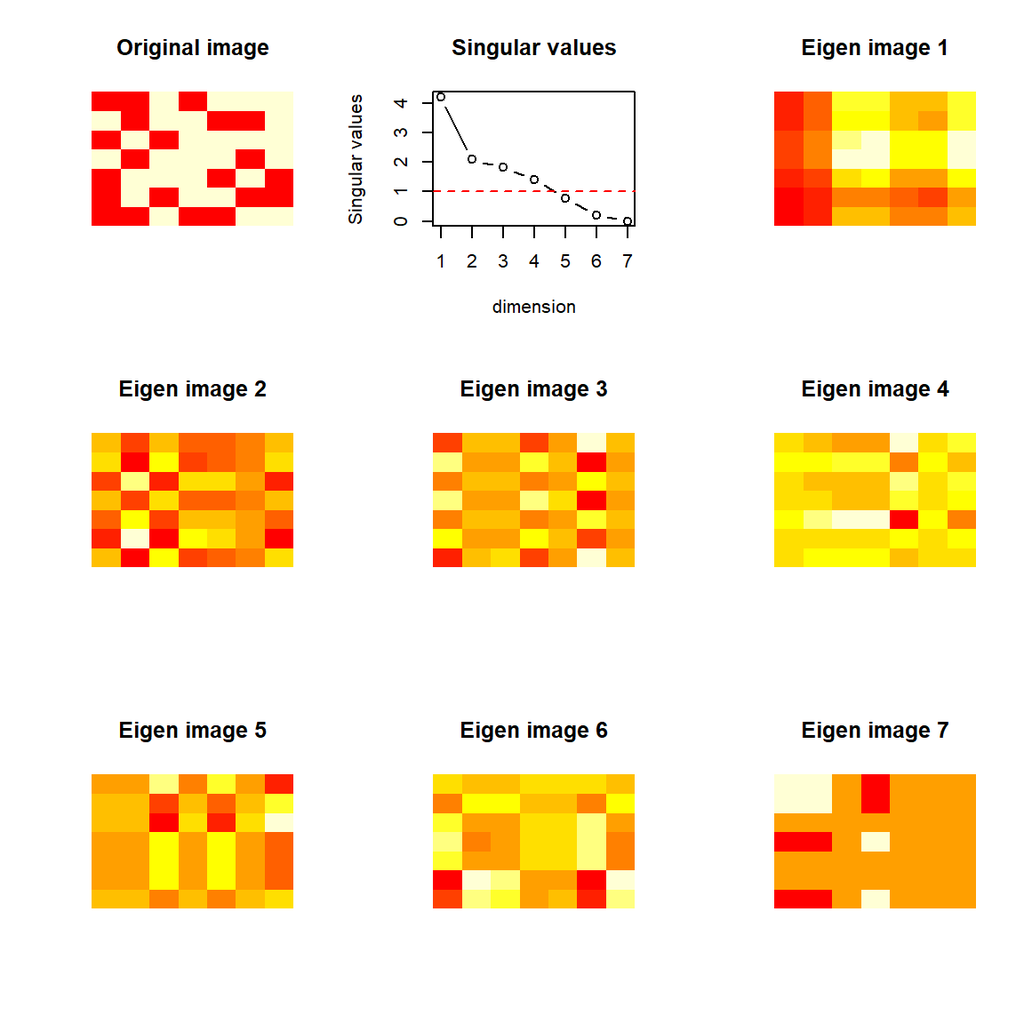

```r
par(mfrow = c(3, 3))
image(A, axes = FALSE, main = "Original image")
plot(A.svd$d, type = "b",
     xlab = "dimension", ylab = "Singular values",
     main = "Singular values")
abline(h = 1, col = 2, lty = 2)
image(A.svd$u[,1]%*%t(A.svd$v[,1]),
      axes = FALSE, main = "Eigen image 1")
image(A.svd$u[,2]%*%t(A.svd$v[,2]),
      axes = FALSE, main = "Eigen image 2")
image(A.svd$u[,3]%*%t(A.svd$v[,3]),
      axes = FALSE, main = "Eigen image 3")
image(A.svd$u[,4]%*%t(A.svd$v[,4]),
      axes = FALSE, main = "Eigen image 4")
image(A.svd$u[,5]%*%t(A.svd$v[,5]),
      axes = FALSE, main = "Eigen image 5")
image(A.svd$u[,6]%*%t(A.svd$v[,6]),
      axes = FALSE, main = "Eigen image 6")
image(A.svd$u[,7]%*%t(A.svd$v[,7]),
      axes = FALSE, main = "Eigen image 7")
```

```r
A.svd$d
```

```
## [1] 4.208937e+00 2.084536e+00 1.820764e+00 1.408889e+00 7.745481e-01
## [6] 1.987147e-01 1.069894e-16
```

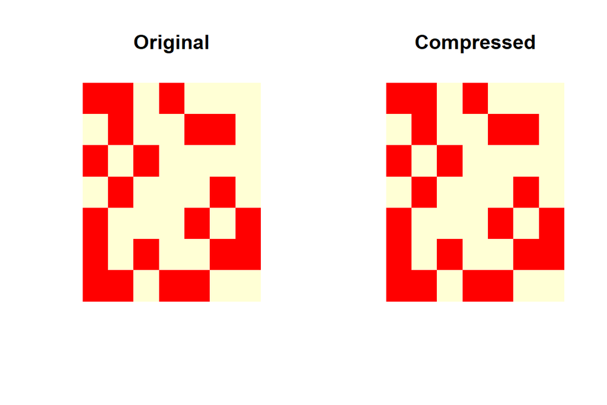

```r
d.tilde <- sum(A.svd$d >= 1)
A.tilde <- round(A.svd$u[,1:d.tilde] %*% diag(A.svd$d[1:d.tilde]) %*% t(A.svd$v[,1:d.tilde]))
par(mfrow = c(1, 2))
image(A, axes = FALSE, main = "Original")
image(A.tilde, axes = FALSE, main = "Compressed")
```

노이즈 제거에도 활용된다.

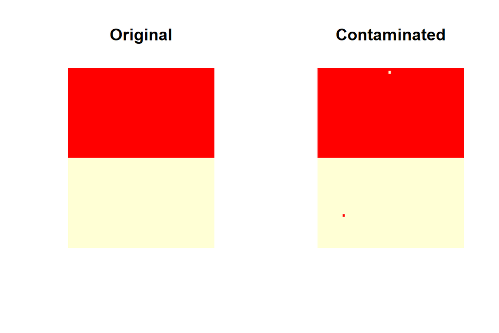

```r
A <- matrix(c(rep(1, 2048), rep(0, 2048)), 64, 64)
par(mfrow = c(1, 2))
image(A, axes = FALSE, main = "Original")
A[32, 63] <- 1 - A[32, 63]
A[12, 12] <- 1 - A[12, 12]
image(A, axes = FALSE, main = "Contaminated")
```

특이값이 1 이상인 성분만 남기는 방식으로 위 이미지에 섞인 노이즈를 제거한다.

```r
A.svd <- svd(A)
str(A.svd)
```

```
## List of 3
##  $ d: num [1:64] 4.52e+01 9.95e-01 9.74e-01 1.39e-14 4.45e-15 ...
##  $ u: num [1:64, 1:64] -0.125 -0.125 -0.125 -0.125 -0.125 ...
##  $ v: num [1:64, 1:64] -0.177 -0.177 -0.177 -0.177 -0.177 ...
```

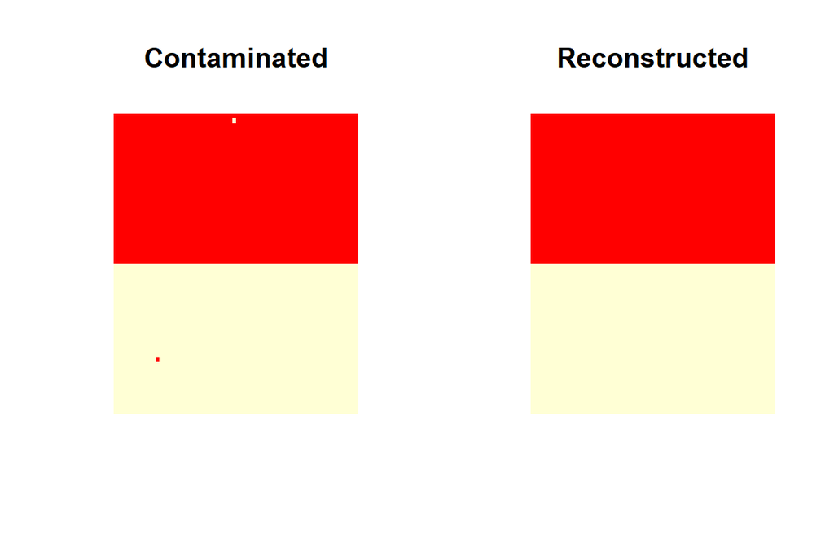

```r
d.tilde <- sum(A.svd$d >= 1)
A.tilde <- round(A.svd$d[1] * A.svd$u[,1:d.tilde] %*% t(A.svd$v[,1:d.tilde]))
par(mfrow = c(1, 2))
image(A, axes = FALSE, main = "Contaminated")
image(A.tilde, axes = FALSE, main = "Reconstructed")
```

[참고] 고유치 분해와 밀접한 관계가 있다.
$$A^\top A = U\Sigma V^\top V\Sigma U^\top = U \Sigma^2 U^\top$$

## 2.2 수치 미분

### 2.2.1 미분 derivative

매끈한 함수 $f$의 미분은 다음과 같이 변화율의 극한으로 정의된다.
$$\frac{d}{dx} f(x) = f'(x) = \lim_{h\rightarrow 0} \frac{f(x+h) - f(x)}{h}$$
따라서, $h\approx 0$에 대해 다음의 근사식이 성립한다.
$$f'(x) \approx \frac{f(x+h) - f(x)}{h}$$
보다 정밀한 근사를 원한다면
$$f'(x) \approx \frac{f(x+h) - f(x-h)}{2h}$$
와 같은 트릭을 쓰면 된다. 실은 이 근사 방법은
$$\frac{f(x+h) - f(x-h)}{2h}
= \frac{\frac{f(x+h) - f(x)}{h} + \frac{f(x) - f(x-h)}{h}}{2}$$
에 의한 것으로 이해할 수 있다.

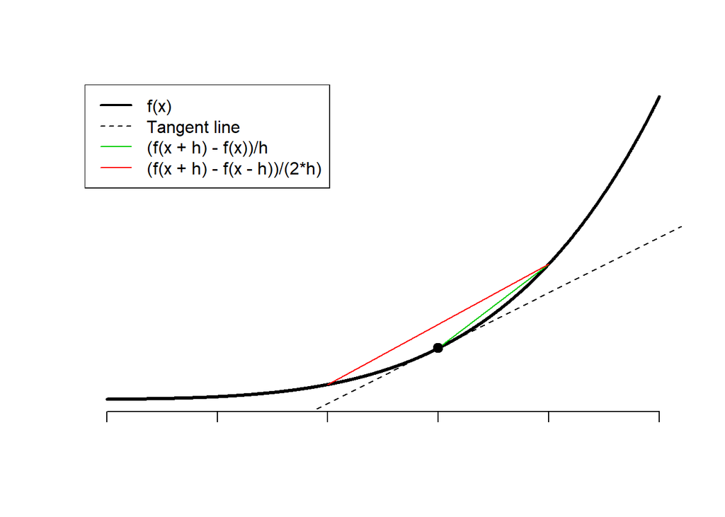

다음은 $f(x) = \exp(-x)$에 대해 $x=1$에서의 미분계수를 구하는 예이다. 실제 도함수는 $f'(x) = -\exp(-x)$이므로 $x=1$에서의 미분계수는 $f'(1) = -e^{-1}\approx -0.367879$이다.

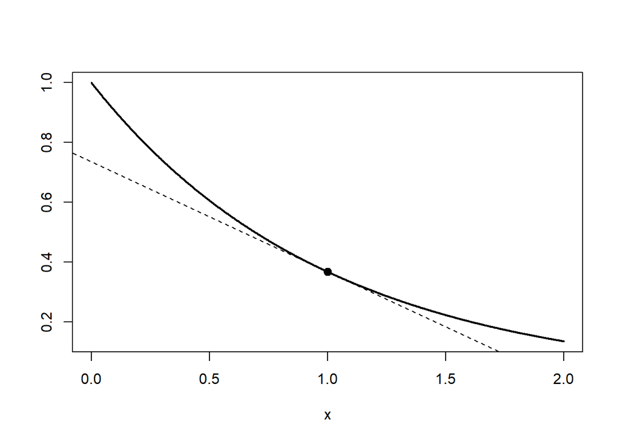

```r
round(-exp(-1), 6)  # 실제 미분계수
```

```
## [1] -0.367879
```

우선 근사식 $f'(x) \approx \frac{f(x+h) - f(x)}{h}$을 적용해보자.

```r
f <- function(x) exp(-x)
h <- 2^(-2*(0:10))
x <- 1
round(rbind(h, (f(x + h) - f(x))/h), 6)
```

```
##        [,1]      [,2]      [,3]      [,4]      [,5]      [,6]      [,7]
## h  1.000000  0.250000  0.062500  0.015625  0.003906  0.000977  0.000244
##   -0.232544 -0.325499 -0.356619 -0.365020 -0.367162 -0.367700 -0.367835
##        [,8]      [,9]     [,10]     [,11]
## h  0.000061  0.000015  0.000004  0.000001
##   -0.367868 -0.367877 -0.367879 -0.367879
```

$h$를 순차적으로 줄여가면서 미분계수의 근사값을 확인해보면 대략 10번째 쯤에서 수렴한 것을 확인할 수 있다. 이번에는 근사식 $f'(x) \approx \frac{f(x+h) - f(x-h)}{2h}$을 적용해보자.

```r
round(rbind(h, (f(x + h) - f(x - h))/(2*h)), 6) # better
```

```
##        [,1]      [,2]      [,3]      [,4]      [,5]      [,6]      [,7]
## h  1.000000  0.250000  0.062500  0.015625  0.003906  0.000977  0.000244
##   -0.432332 -0.371724 -0.368119 -0.367894 -0.367880 -0.367879 -0.367879
##        [,8]      [,9]     [,10]     [,11]
## h  0.000061  0.000015  0.000004  0.000001
##   -0.367879 -0.367879 -0.367879 -0.367879
```

이번에는 대략 6번째 반복에서 수렴한 것으로 보인다. 예상한대로 앞의 근사식보다 훨씬 빨리 수렴에 도달했다.

아래 코드 청크는 수치미분을 R 코드로 직접 구현해 함수 $f(x) = \sin x$ 에 적용한 예이다.

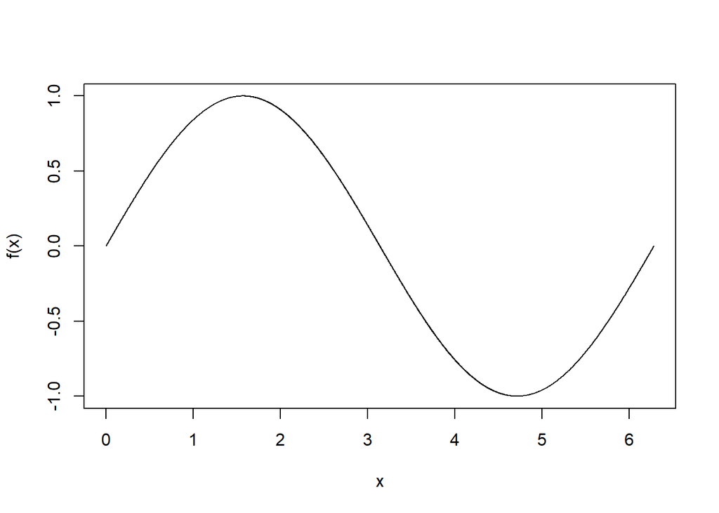

```r
derivative <- function(f, x, tol = 1e-8, tol.h = 5e-10)
{
  h <- 1e-3
  der0 <- (f(x + h) - f(x - h))/(2*h)
  iter <- 0
  while(1) {
    iter <- iter + 1
    h <- 0.25*h
    der1 <- (f(x + h) - f(x - h))/(2*h)
    diff <- max(abs(der1 - der0))
    if (diff < tol | h < tol.h ) {
      ans <- der1
      break
    }
  }

  return(list(deriv = ans, diff = diff, h = h, iter = iter))
}

x <- seq(from = 0, to = 2*pi, by = 0.0025)
#f <- function(x) x^3 - x^2
f <- function(x) sin(x)

der <- derivative(f, x)
plot(x, f(x), type = 'l')
```

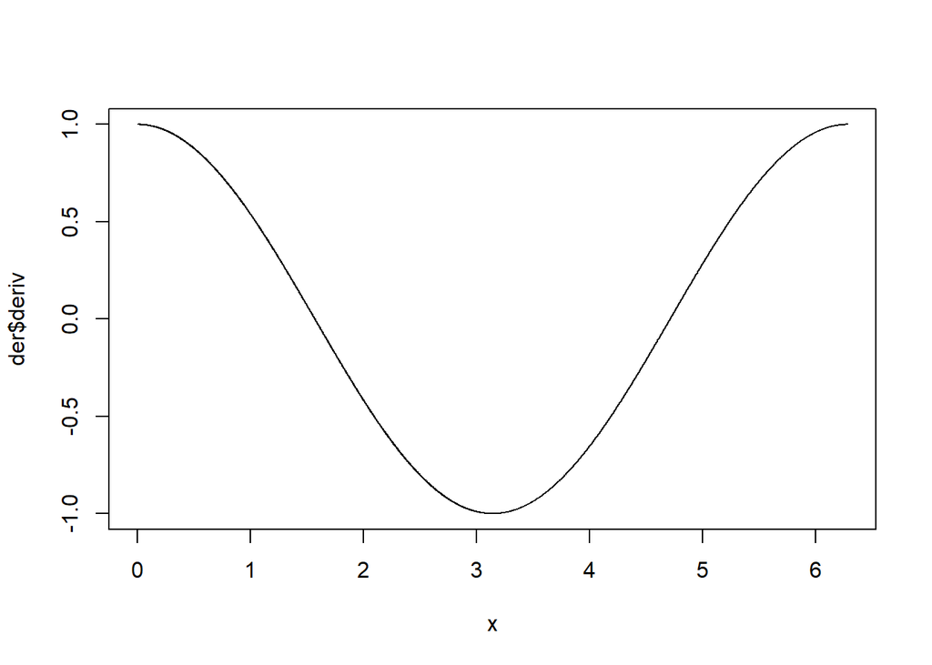

```r
plot(x, der$deriv, type = 'l')
```

### 2.2.2 편미분 partial derivative

다변수 함수 $f({\mathbf x})$의 미분으로 확장하자면, 편미분(partial derivative) 즉 특정 변수를 제외한 나머지 변수를 상수로 생각하여 미분하는 것이 쉬운 방법이다.
$$\nabla f({\mathbf x})
= \left(\frac{\partial f}{\partial x_i}({\mathbf x})\right)_{i=1,2,...,d}$$
예를 들어 $f({\mathbf x}) = f(x_1, x_2) = x_1^2 + x_1x_2 + x_2^2$의 편미분은
$$\frac{\partial f}{\partial x_1}({\mathbf x}) = 2x_1 + x_2, \quad
\frac{\partial f}{\partial x_2}({\mathbf x}) = x_1 + 2x_2$$
로 구해진다. 즉,
$$\nabla f({\mathbf x}) = \left(2x_1 + x_2, \,\,x_1 + 2x_2\right)^\top$$
예를 들어 $(2, 2)$에서의 편미분계수 $\frac{\partial f}{\partial x_1}(2, 2)$의 값은 $2x_1 + x_2=2\times 2+ 2 = 6$이다.

다음은 위의 함수 $f$에 대해 편미분계수 $\frac{\partial f}{\partial x_1}(2, 2)$를 수치적으로 계산하는 예이다. 우선 함수 $f$의 그래프를 살펴보면 아래 그림과 같다.

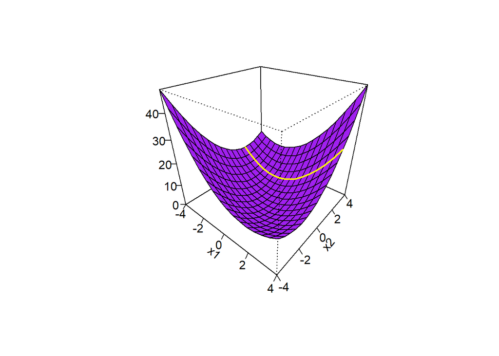

```r
f <- function(x1, x2){
  x1^2 + x1*x2 + x2^2
}

x1 <- seq(from = -4, to = 4, by = 0.5)
x2 <- seq(from = -4, to = 4, by = 0.5)
persp(x1, x2, outer(x1, x2, f),
      col = "purple", ticktype = "detailed",
      zlab = "", theta = 40, phi = 30) -> res
lines(trans3d(x1, 2, f(x1, 2), res), col = "yellow", lwd = 2)
```

곡면 위에 보이는 노란색 실선은 $x_2 = 2$인 경우의 단면, 즉 $f(x_1, 2)$의 궤적을 나타낸 것이다. $\frac{\partial f}{\partial x_1}(2, 2)$은 이 궤적에서 구한 $x_1 = 2$에서의 미분계수가 된다.

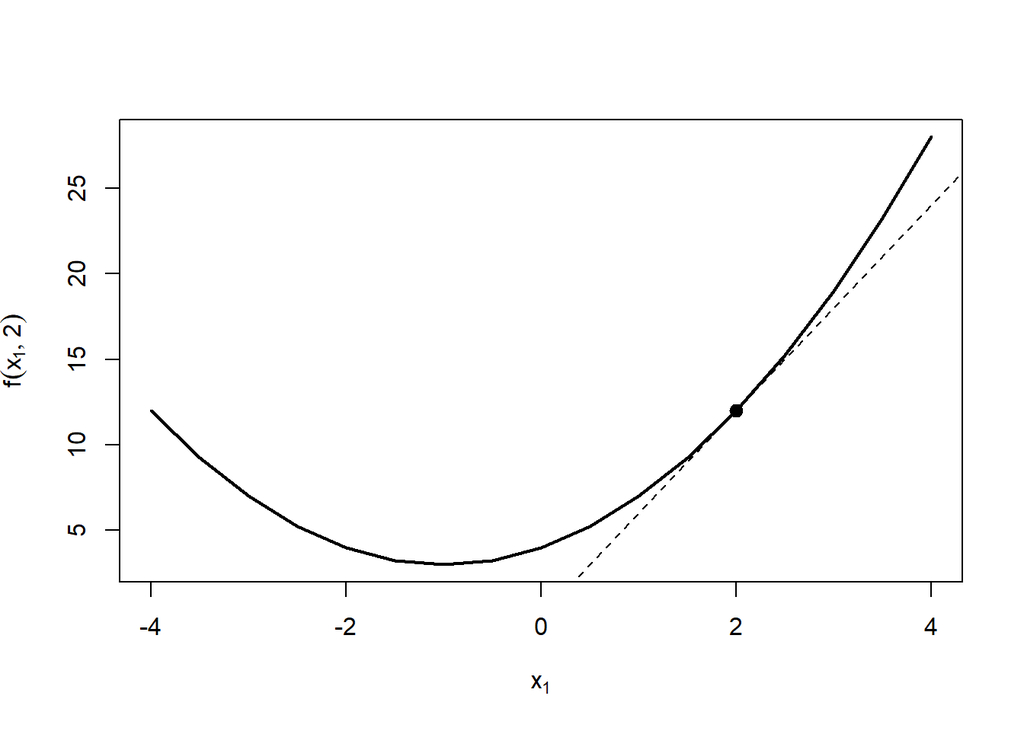

```r
fs <- function(x) f(x, 2)
derivative(fs, 2)  # very good!
```

```
## $deriv
## [1] 6
##
## $diff
## [1] 8.881784e-13
##
## $h
## [1] 0.00025
##
## $iter
## [1] 1
```

## 2.3 수치 적분

### 2.3.1 직사각형/사다리꼴 quadrature 방법

정적분 $\int_a^b f(x) dx$를 수치해석적으로 계산하는 방법을 생각해보자. 가장 간단한 방법은 구분구적법에 의한 직사각형 근사 방법이다.
$$\int_a^b f(x) dx \approx \sum_{i=1}^n f(x_i)\times {\rm \delta}$$
단, $\delta = (b - a)/n$, $x_i = a + (i-1)\delta$, $i=1,2,...,n$ 이다.

이를 좀더 정교화한 것이 사다리꼴 근사이다.

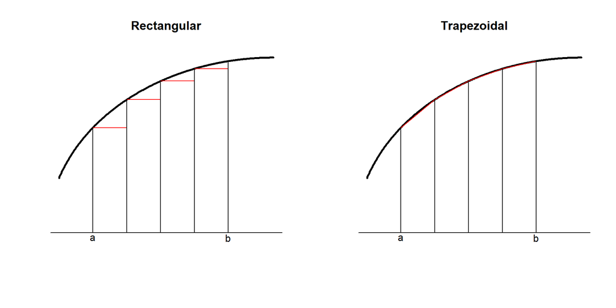

다음은 위 수치 적분 방법들을 사용해 $\int_0^{\pi/2} \sin x \,\,dx$를 계산한 예이다. 실제 적분값은 1이다.

```r
f <- function(x) sin(x)
a <- 0; b <- pi/2; inc <- 2e-6
x <- seq(from = a, to = b, by = inc)
y <- f(x)
n <- length(y)
integ.rect <- sum(y[-n]*inc)
integ.trpz <- sum(y*inc) - 0.5*(y[1] + y[n])*inc
round(c(integ.rect, integ.trpz), 6)
```

```
## [1] 0.999999 1.000000
```

### 2.3.2 Gaussian quadrature 방법

함수 $f$가 구간 $[-1, 1]$에서 $(2n-1)$차 이하의 다항식으로 잘 근사될 수 있을 때, 이 구간에서의 정적분을 아래와 같이 근사하는 방법이다.
$$\int_{-1}^1 f(x)\,dx \approx \sum_{i=1}^n w_i f(x_i)$$
$w_i$와 $x_i$의 값은 아래 표와 정리되어 있는 것을 이용하면 된다. 만일 함수 $f$가 $(2n-1)$차 이하의 다항식의 경우에는 위 관계는 등식이 된다.

Gauss-Legendre:

| $n$ | $w_i$ | $x_i$ |
| --- | --- | --- |
| 2 | $w_1 = 1$, $w_2 = 1$ | $x_1 = -0.577350269$, $x_2 = +0.577350269$ |
| 3 | $w_1 = 0.5555556$, $w_2 = 0.8888889$, $w_3 = 0.5555556$ | $x_1 = -0.774596669$, $x_2 = 0$, $x_3 = +0.774596669$ |
| 4 | $w_1 = 0.3478548$, $w_2 = 0.6521452$, $w_3 = 0.6521452$, $w_4 = 0.3478548$ | $x_1 = -0.861136312$, $x_2 = -0.339981044$, $x_3 = +0.339981044$, $x_4 = +0.861136312$ |
| 5 | $w_1 = 0.2369269$, $w_2 = 0.4786287$, $w_3 = 0.5688889$, $w_4 = 0.4786287$, $w_5 = 0.2369269$ | $x_1 = -0.906179846$, $x_2 = -0.538469310$, $x_3 = 0$, $x_4 = +0.538469310$, $x_5 = +0.906179846$ |
| 6 | $w_1 = 0.1713245$, $w_2 = 0.3607616$, $w_3 = 0.4679139$, $w_4 = 0.4679139$, $w_5 = 0.3607616$, $w_6 = 0.1713245$ | $x_1 = -0.932469514$, $x_2 = -0.661209386$, $x_3 = -0.238619186$, $x_4 = +0.238619186$, $x_5 = +0.661209386$, $x_6 = +0.932469514$ |

위 표의 숫자들은 다음과 같이 구한 결과물이다. $P_n$을 $n$차 Legendre 다항식이라 할 때, $x_i$는 방정식
$$P_n(x) = 0$$
의 해이고, $w_i$는
$$w_i = \frac{2}{(1-x_i^2)\{P_n'(x_i)\}^2}$$
이다.

등식
$$\int_a^b f(x) \,dx = \frac{b-a}{2} \int_{-1}^1 f\left(\frac{b-a}{2}x + \frac{b+a}{2}\right)\,dx$$
가 성립하므로 $[-1, 1]$이 아닌 임의의 구간에서의 정적분에 대해서도 가우스구적법을 이용할 수 있다. 위 예제의 sine 함수를 적분하는 문제에 적용해보자.

```r
GaussianQuadratureIntegral <- function(f, lower, upper, n = 5)
{
  if (n == 2) {
    w <- c(1, 1)
    x <- c(-0.577350269, 0.577350269)
  } else if (n == 3) {
    w <- c(0.5555556, 0.8888889, 0.5555556)
    x <- c(-0.774596669, 0, 0.774596669)
  } else if (n == 4) {
    w <- c(0.3478548, 0.6521452, 0.6521452, 0.3478548)
    x <- c(-0.861136312, -0.339981044, 0.339981044, 0.861136312)
  } else if (n == 5) {
    w <- c(0.2369269, 0.4786287, 0.5688889, 0.4786287, 0.2369269)
    x <- c(-0.906179846, -0.538469310, 0, 0.538469310, 0.906179846)
  } else if (n == 6) {
    w <- c(0.1713245, 0.3607616, 0.4679139, 0.4679139, 0.3607616, 0.1713245)
    x <- c(-0.932469514, -0.661209386, -0.238619186, 0.238619186, 0.661209386, 0.932469514)
  } else {
    cat("Check n: 2, 3, ..., 6\n")
    return(NA)
  }
  ans <- 0.5*(upper - lower)*sum(w*f(0.5*((upper - lower)*x + (upper + lower))))
  return(ans)
}

GaussianQuadratureIntegral(f, 0, pi/2, n = 2)
```

```
## [1] 0.9984726
```

```r
GaussianQuadratureIntegral(f, 0, pi/2, n = 3)
```

```
## [1] 1.000008
```

```r
GaussianQuadratureIntegral(f, 0, pi/2, n = 4)
```

```
## [1] 1
```

```r
GaussianQuadratureIntegral(f, 0, pi/2, n = 5)
```

```
## [1] 1
```

```r
GaussianQuadratureIntegral(f, 0, pi/2, n = 6)
```

```
## [1] 1
```

`gss` 패키지의 `gauss.quad()` 함수를 이용할 수도 있다.

```r
library(gss)
gauss.quad(size = 5, interval = c(-1, 1))
```

```
## $pt
## [1] -0.9061798 -0.5384693  0.0000000  0.5384693  0.9061798
##
## $wt
## [1] 0.2369269 0.4786287 0.5688889 0.4786287 0.2369269
```

```r
gq <- gauss.quad(size = 5, interval = c(0, pi/2))
sum(gq$wt*f(gq$pt))
```

```
## [1] 1
```

### 2.3.3 `integrate()` 함수 이용

`integrate()` 함수는 adaptive quadrature 방법으로 정적분을 계산해준다. Adaptive quadrature 방법을 정리하면 다음과 같다.

1. 구적법으로 계산한 근사값의 오차의 추정치를 계산
2. 미리 설정한 tolerance 보다 크면 적분구간을 반으로 쪼개어 각각의 구간에 대해 구적법을 실시
3. 각 구간에서의 오차 추정치가 tolerance를 만족할 때까지 적분구간을 반으로 쪼개 구적법을 적용하는 것을 반복

다음은 `integrate()` 함수를 이용해 sine 함수의 정적분을 구한 예이다.

```r
integ <- integrate(f = sin, lower = 0, upper = pi/2, abs.tol = 1e-5)
str(integ)
```

```
## List of 5
##  $ value       : num 1
##  $ abs.error   : num 1.11e-14
##  $ subdivisions: int 1
##  $ message     : chr "OK"
##  $ call        : language integrate(f = sin, lower = 0, upper = pi/2, abs.tol = 1e-05)
##  - attr(*, "class")= chr "integrate"
```

```r
print(integ$value)
```

```
## [1] 1
```

무한구간에서의 적분도 계산할 수 있다.

```r
g <- function(x) exp(-x)
integrate(g, lower = 0, upper = Inf)
```

```
## 1 with absolute error < 5.7e-05
```

```r
integrate(dnorm, lower = -Inf, upper = -1.96)
```

```
## 0.0249979 with absolute error < 1.9e-05
```

### 2.3.4 몬테카를로 방법

```r
n <- 1e6
x <- rexp(n)
mean(x)
```

```
## [1] 1.001125
```

몬테카를로 적분에 의한 근사값은 표본평균에 대한 통계 이론(중심극한정리, central limit theorem)에 의해 정밀도를 함께 제시할 수 있다. 예를 들어 신뢰도 95%에서 오차의 한계는 다음과 같이 구할 수 있다.

```r
1.96*sd(x)/sqrt(n)
```

```
## [1] 0.001963215
```

```r
c(mean(x) - 1.96*sd(x)/sqrt(n), mean(x) + 1.96*sd(x)/sqrt(n))
```

```
## [1] 0.9991614 1.0030879
```

다변수 함수의 수치적분 문제로 쉽게 확장되며, 특히 베이지안 통계학의 사후분포에 기반한 추론에 유용한 도구이다.

### 2.3.5 Importance sampling

Importance sampling의 아이디어는 몬테카를로 적분에 근거한 것이다. 즉,
$$\int_a^b f(x) dx = \int_a^b \frac{f(x)}{g(x)} g(x) dx
\approx \frac{1}{n} \sum_{i=1}^n \frac{f(y_i)}{g(y_i)}$$
단, $y_i$는 $g$를 밀도함수로 갖는 분포에서 추출한 난수이다. 물론 $g$의 토대(support)는 구간 $[a, b]$이다. 근사값이 $\frac{f(y_i)}{g(y_i)}$의 표본평균에 해당하기 때문에 표준오차는 ${\rm sd}(\frac{f(y)}{g(y)})/\sqrt{n}$가 됨을 이용해 근사값의 정확도를 평가할 수 있다. 난수를 발생시키게 되는 밀도함수 $g$의 형태에 따라 근사의 정밀도가 결정되는데, 적분 구간 내에서 $|f|$와 형태가 비슷한 $g$를 선택해 $f(x)/g(x)$가 변화가 심하지 않게 만들어 주는 것이 유리하다.

다음은 $\int_0^1 e^{-x}/(1 + x^2)\,dx$를 importance sampling을 이용해 수치적으로 계산한 예이다. 우선 $g(x)$를 균일분포의 밀도함수로 선택한 경우를 살펴보자.

```r
f <- function(x) exp(-x)/(1 + x*x)*(x >= 0)*(x <= 1)
n <- 1e6
y <- runif(n)
g1 <- function(y) dunif(y)

cat("근사값:", round(mean(f(y)/g1(y)), 6),
    "  s.e.:", round(sd(f(y)/g1(y))/sqrt(n), 6), "\n")
```

```
## 근사값: 0.524874   s.e.: 0.000245
```

이번에는 $g(x)$를 구간 $[0,1]$로 절단한 지수분포의 밀도함수로 선택해보자

```r
u <- runif(n); y <- -log(1 - u*(1 - exp(-1)))
g2 <- function(y) exp(-y)/(1 - exp(-1)) # better
cat("근사값:", round(mean(f(y)/g2(y)), 6),
    "  s.e.:", round(sd(f(y)/g2(y))/sqrt(n), 6), "\n")
```

```
## 근사값: 0.524908   s.e.: 9.7e-05
```

$g(x)$를 균일분포로 선택한 경우보다 훨씬 신뢰할 만한 결과임을 확인할 수 있다. 그 이유는 다음의 $f(x)/g(x)$를 비교한 그림에 의해 설명 가능하다.

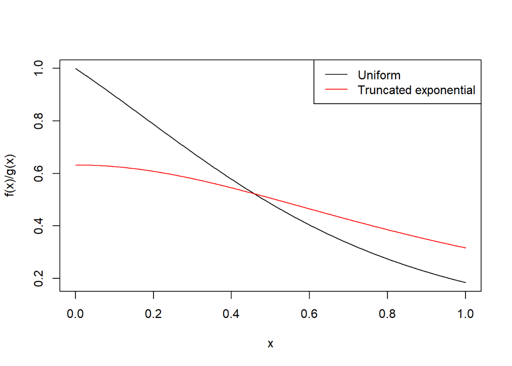

```r
x <- seq(from = 0, to = 1, by = 0.001)
plot(x, f(x)/g1(x), type = "l", ylab = "f(x)/g(x)")
lines(x, f(x)/g2(x), col = 2)
legend("topright", c("Uniform", "Truncated exponential"),
       col = 1:2, lty = rep(1, 2))
```

## 2.4 방정식 해 구하기

이 절에서는 방정식 $f(x) = 0$의 수치 해를 구하는 방법을 다룬다.

### 2.4.1 Bisection search

함수 $f$가 연속함수이면, 구간 $[a,b]$에 대해 함수 값 $f(a)$와 $f(b)$의 부호가 서로 다르면 방정식 $f(x) = 0$의 해가 구간 내에 존재한다는 것을 담보하게 된다. 따라서 후보 구간의 중점 $c=(a+b)/2$를 기준으로 구간을 둘로 나눈 후 끝점에서의 함수값의 부호가 서로 다른 부분구간을 선택하고, 그 구간을 새로운 후보구간으로 해 다시 탐색을 시작하는 방식의 알고리즘이다. 후보 구간의 길이를 절반으로 줄여 가는 과정을 반복하는 알고리즘이기 때문에 bisection이라는 이름을 갖게 되었다.

아래 예제는 $x^2 - 1 = 0$의 해를 구간 $[0, 3]$에서 찾는 예이다.

```r
f <- function(x) x^2 - 1

a <- 0; b <- 3
iter <- 0; max.iter <- 1000; tol <- 1e-5
r <- seq(from = a, to = b, length = 3)
y <- c(f(r[1]), f(r[2]), f(r[3]))

if ( y[1]*y[3] > 0 ) stop("f does not have opposite sign at endpoints")

while (iter < max.iter & abs(y[2]) > tol ) {
  iter <- iter + 1
  if ( y[1]*y[2] < 0 ) {
    r[3] <- r[2]; y[3] <- y[2]
  } else {
    r[1] <- r[2]; y[1] <- y[2]
  }
  r[2] <- (r[1] + r[3])/2
  y[2] <- f(r[2])
  cat("Iteration ", iter, ":", "x = ", round(r[2], 4), "f(x) = ", round(y[2], 4), "\n")
}
```

```
## Iteration  1 : x =  0.75 f(x) =  -0.4375
## Iteration  2 : x =  1.125 f(x) =  0.2656
## Iteration  3 : x =  0.9375 f(x) =  -0.1211
## Iteration  4 : x =  1.0312 f(x) =  0.0635
## Iteration  5 : x =  0.9844 f(x) =  -0.031
## Iteration  6 : x =  1.0078 f(x) =  0.0157
## Iteration  7 : x =  0.9961 f(x) =  -0.0078
## Iteration  8 : x =  1.002 f(x) =  0.0039
## Iteration  9 : x =  0.999 f(x) =  -0.002
## Iteration  10 : x =  1.0005 f(x) =  0.001
## Iteration  11 : x =  0.9998 f(x) =  -5e-04
## Iteration  12 : x =  1.0001 f(x) =  2e-04
## Iteration  13 : x =  0.9999 f(x) =  -1e-04
## Iteration  14 : x =  1 f(x) =  1e-04
## Iteration  15 : x =  1 f(x) =  0
## Iteration  16 : x =  1 f(x) =  0
## Iteration  17 : x =  1 f(x) =  0
```

### 2.4.2 Newton-Raphson method

매끈한 함수 $f$에 의해 표현된 방정식 $f(x) = 0$이 주어졌다고 가정하자. $x = x_0$ 근방에서 일차 테일러 전개를 실시하면 다음의 근사식을 얻게 된다.
$$f(x) \approx f(x_0) + f'(x_0) (x - x_0)$$
이 근사식을 정리하면 다음과 같은 업데이트 공식을 얻을 수 있다.
$$x \leftarrow x_0 - f(x_0)/f'(x_0)$$
아래 예제는 위 업데이트 알고리즘을 이용해 $x^2 - 1 = 0$의 해를 찾는 예이다. 초기치로 $x_0 = 2$를 사용했다.

```r
f <- function(x) x^2 - 1
f1d <- function(x) 2*x

iter <- 0; max.iter <- 1000
dd <- 1000; tol <- 1e-6
x0 <- 2
x <- rep(NA, max.iter)

while ( abs(dd) > tol & iter <= max.iter) {
  iter <- iter + 1
  dd <-  f(x0)/f1d(x0)
  x[iter] <- x0 <- x0 - dd
}
cat(x0, "(# of iterations:", iter, ")\n")
```

```
## 1 (# of iterations: 5 )
```

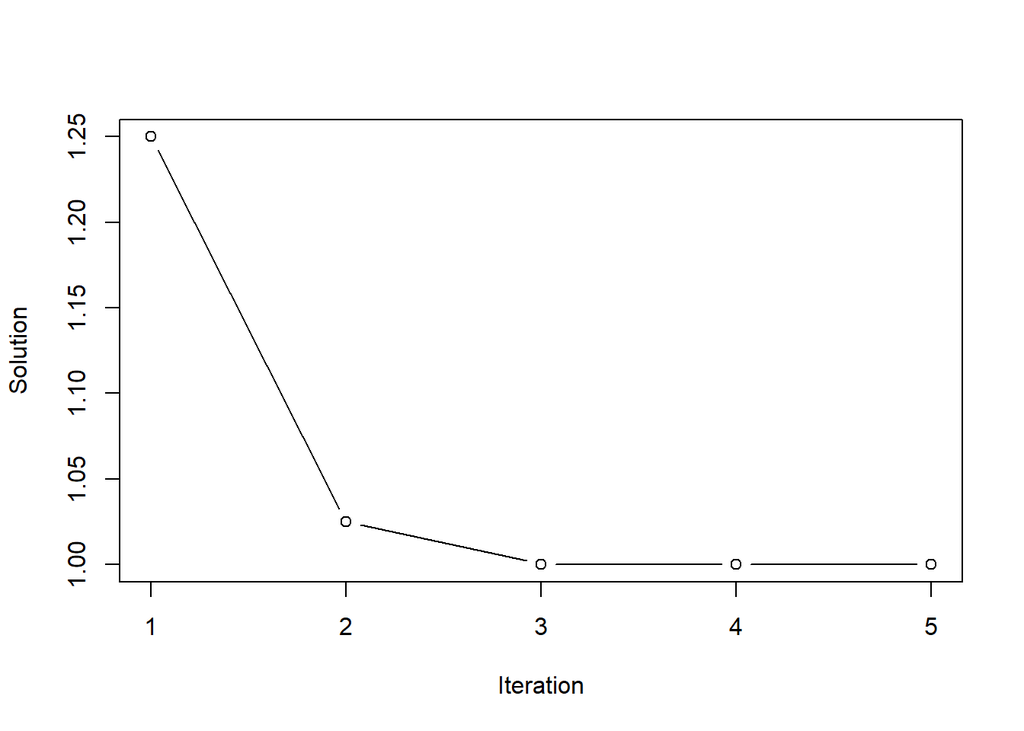

```r
plot(x[1:iter], type = "b", xlab = "Iteration", ylab = "Solution")
```

### 2.4.3 `uniroot()` 함수

`uniroot()` 함수는 Brent method를 이용한 해를 구해준다. Brent method는 bisection method에 secant method와 inverse quadratic interpolation을 결합한 방법이다. 이 함수를 이용해 $x^2 - 1 = 0$의 해를 구간 $[0, 3]$에서 찾는 예이다.

```r
uniroot(f, lower = 0, upper = 3, tol = 1e-6)
```

```
## $root
## [1] 1
##
## $f.root
## [1] -4.944039e-09
##
## $iter
## [1] 9
##
## $init.it
## [1] NA
##
## $estim.prec
## [1] 5e-07
```

## 2.5 최적화

### 2.5.1 Newton-Raphson method

아래로 볼록인 함수 $f({\mathbf x})$의 최소값을 찾는 문제를 생각해보자. $f({\mathbf x})$가 매끈해서 미분 가능한 경우라면 방정식
$$\nabla f({\mathbf x}) = {\mathbf 0}$$
의 해를 찾는 문제로 바꿔 생각할 수 있다. 이 방정식의 좌변에 대해 ${\mathbf x}_0$ 근처에서 1차-테일러 급수 전개를 실시하면
$$\nabla f({\mathbf x}) \approx \nabla f({\mathbf x}_0) + \nabla^2 f({\mathbf x}_0)({\mathbf x} - {\mathbf x}_0)$$
가 되므로
$${\mathbf x} \,\,\leftarrow\,\, {\mathbf x}_0 - \left\{\nabla^2 f({\mathbf x}_0)\right\}^{-1} \nabla f({\mathbf x}_0)$$
의 업데이트 공식을 얻을 수 있다. 적절한 초기치를 정해 위 업데이트 공식을 수렴 조건을 만족할 때까지 반복 적용해 최적해를 얻는다. 매우 빠른 속도로 해를 찾을 수 있지만, 다변수 함수의 최적화 문제에서 이차미분행렬 $\nabla^2 f({\mathbf x}_0)$의 역행렬을 계산하는 과정에서 어려움이 발생할 수 있다.

아래 예제는 $f(x) = x^4 + 3x^2$의 최소값을 찾는 예이다.

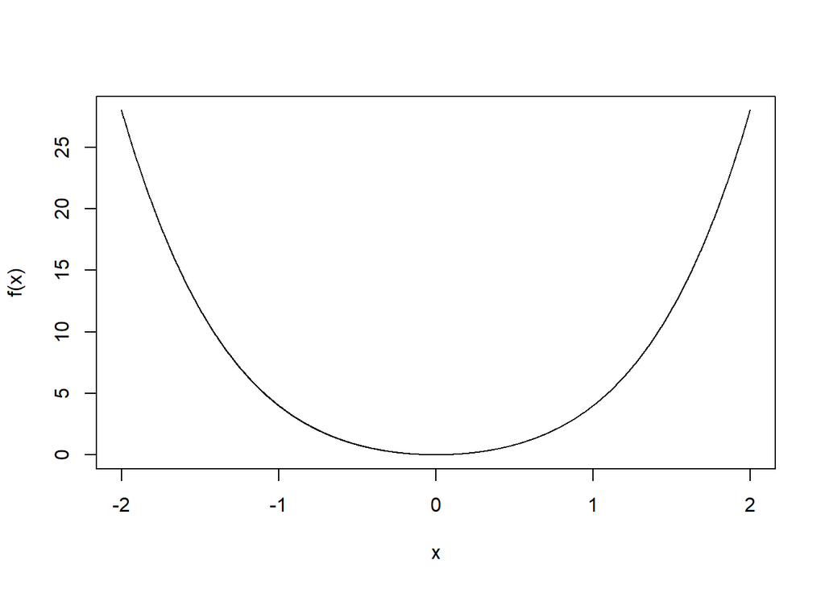

```r
f <- function(x) x^4 + 3*x^2
f1d <- function(x) 4*x^3 + 6*x
f2d <- function(x) 12*x^2 + 6

x <- seq(from = -2, to = 2, by = 0.002)
plot(x, f(x), type = 'l')
```

```r
dd <- 1000; tol <- 1e-6
iter <- 0; max.iter <- 1000

x0 <- 1
x <- rep(NA, max.iter)

while ( abs(dd) > tol & iter <= max.iter) {
  iter <- iter + 1
  dd <-  f1d(x0)/f2d(x0)
  x[iter] <- x0 <- x0 - dd
}
cat(x0, "(# of iterations:", iter, ")\n")
```

```
## 0 (# of iterations: 5 )
```

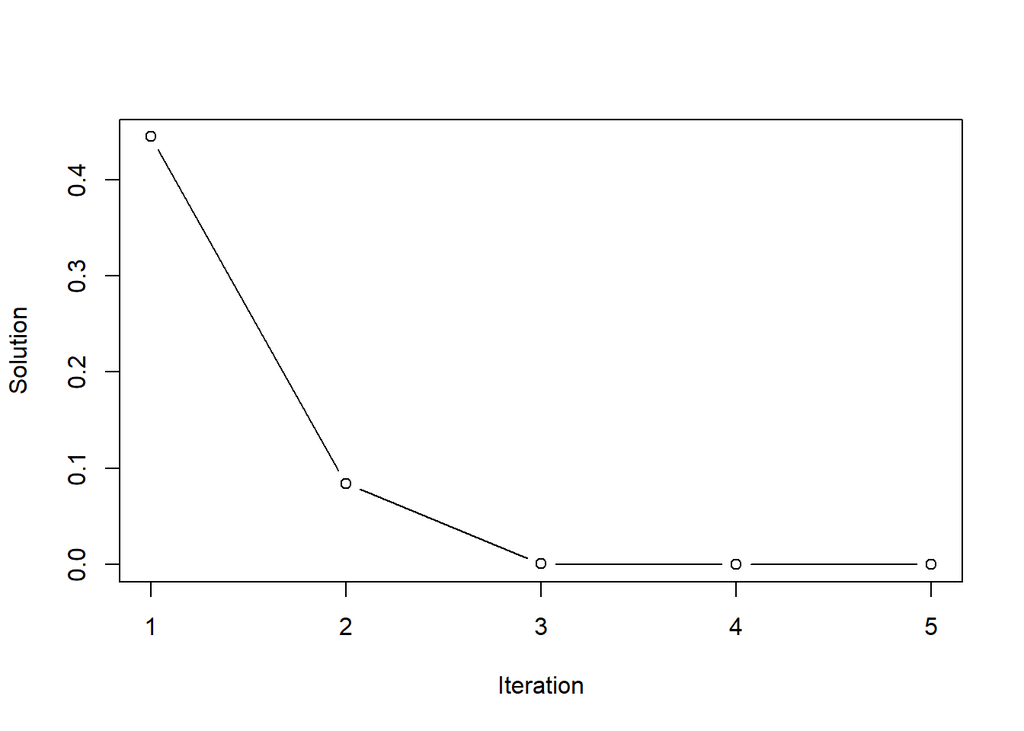

```r
plot(x[1:iter], type = "b", xlab = "Iteration", ylab = "Solution")
abline(h = pi, col = 2, lty = 2)
```

### 2.5.2 Gradient method

역시 아래로 볼록인 함수 $f({\mathbf x})$의 최소값을 찾는 문제에 국한해 생각해보자. 적절한 초기치로부터 출발해 그래디언트가 $\mathbf 0$이 되는 방향으로 해를 업데이트하는 방법이다. Gradient descent 알고리즘이라 한다. 적절한 양의 상수 $\eta$에 대해
$${\mathbf x} \leftarrow {\mathbf x}_0 - \eta \nabla f({\mathbf x}_0)$$
적절한 초기치로 출발해 수렴 조건을 만족할 때까지 위 업데이트 공식을 반복 적용해 최적해를 얻는다. 이차미분에 관련된 문제가 없어 간편하지만 학습률(learning rate) $\eta$를 잘 설정해야 하는 작업이 추가된다.

```r
f <- function(x) x^4 + 3*x^2
f1d <- function(x) 4*x^3 + 6*x

eta <- 0.05; dd <- 1000; tol <- 1e-6
iter <- 0; max.iter <- 1000

x0 <- 1
x <- rep(NA, max.iter)

while ( abs(dd) > tol & iter <= max.iter) {
  iter <- iter + 1
  dd <- f1d(x0)
  x[iter] <- x0 <- x0 - eta*dd
}
cat(x0, "(# of iterations:", iter, ")\n")
```

```
## 9.571988e-08 (# of iterations: 44 )
```

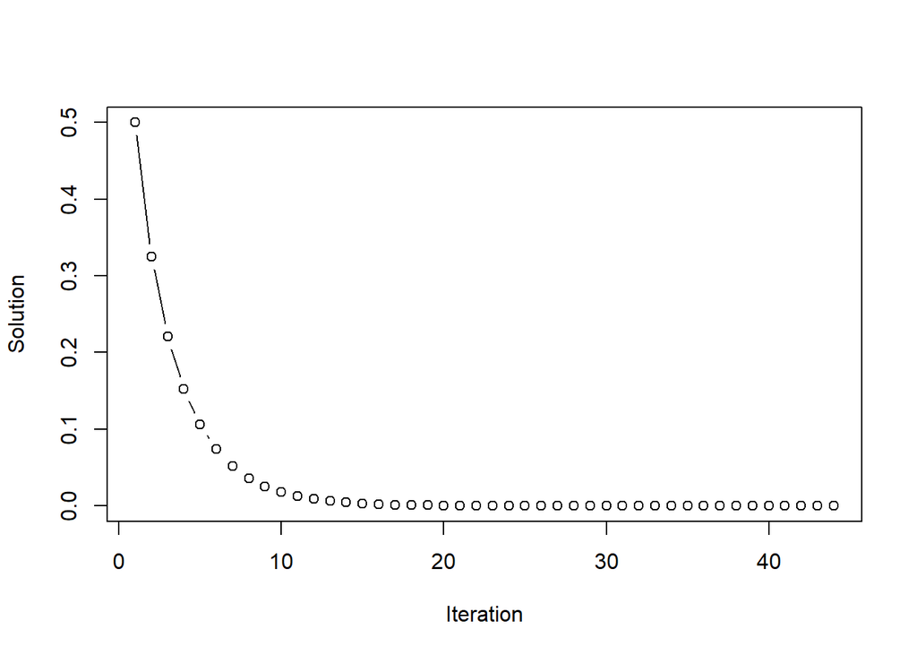

```r
plot(x[1:iter], type = "b", xlab = "Iteration", ylab = "Solution")
```

### 2.5.3 Golden section search

단변수 함수에 사용하는 최적화 기법이다. 후보 구간을 황금비에 따라 분할해가면서 최적해를 찾는 알고리즘이다. 미분을 고려할 필요가 없으며 빠른 속도로 해를 찾을 수 있는 방법이다.

```
## -5.795832e-09 (# of iterations: 40 )
```

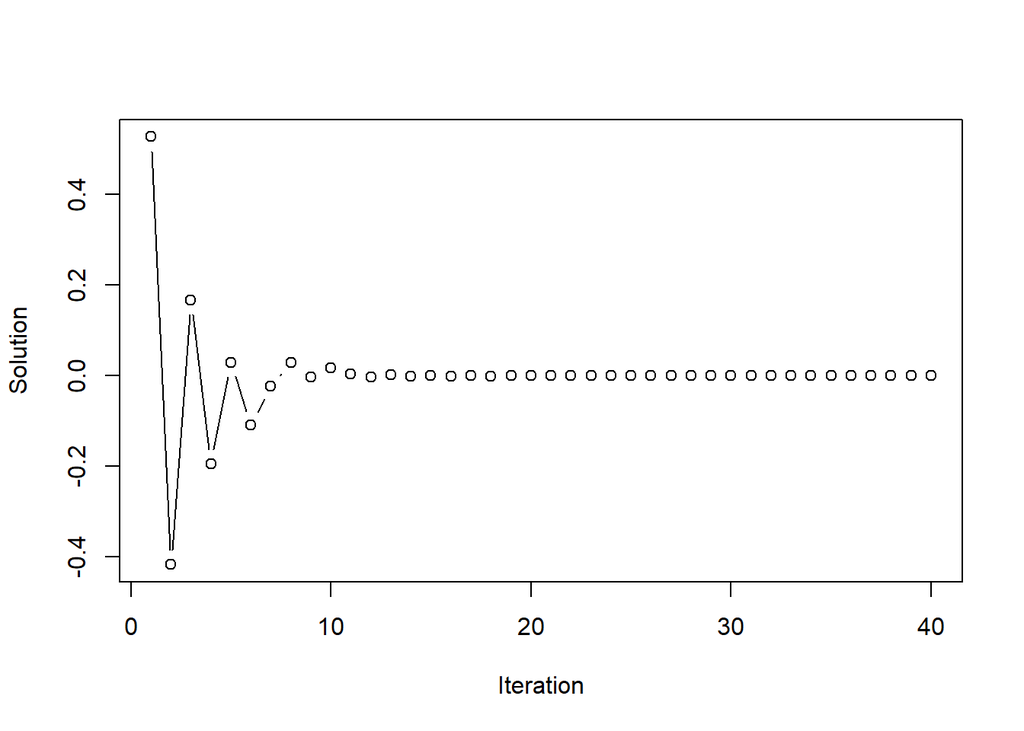

```
## $optimal
## [1] -5.795832e-09
##
## $objective
## [1] 1.00775e-16
##
## $iter
## [1] 40
```

```r
GoldenSection <- function(f, a, b, tol = 1e-8, max.iter = 1000, doplot = TRUE)
#   golden section search
#   to find the minimum of f on [a,b]
#   f: a strictly unimodal function on [a,b]
{
  gr <- (sqrt(5) + 1) / 2
  c <- b - (b - a) / gr
  d <- a + (b - a) / gr
  iter <- 0
  x <- rep(NA, max.iter)
  while (abs(c - d) > tol) {
    iter <- iter + 1
    ifelse(f(c) < f(d), b <- d, a <- c)
    c <- b - (b - a) / gr
    d <- a + (b - a) / gr
    x[iter] <- (a + b)/2
  }
  cat(x[iter], "(# of iterations:", iter, ")\n")
  if (doplot) plot(x[1:iter], type = "b", xlab = "Iteration", ylab = "Solution")

  return(list(optimal = x[iter], objective = f(x[iter]), iter = iter))
}

GoldenSection(f, a = -5, b = 3)
```

### 2.5.4 `optimise()`, `optim()` 함수 이용

`optimize()`함수는 golden section search 와 successive parabolic interpolation 을 결합한 방식으로 최적해를 찾아준다.

```r
optimize(f, interval = c(-1, 1), maximum = FALSE, tol = 1e-6)
```

```
## $minimum
## [1] 0
##
## $objective
## [1] 0
```

`optim()`함수는 다변수 함수의 최적화 문제를 해결해준다. `method =` 옵션을 통해 Nelder–Mead (default), quasi-Newton, conjugate-gradient, simulated annealing algorithms 등을 선택적으로 사용할 수 있다. Box-constrained optimization을 위한 옵션도 제공한다. 아래 예제는 비선형회귀함수 $y = \beta_0 / (1 + \beta_1 x)$에 대한 최소제곱 추정을 모의실험 데이터에 적용한 예이다. Quasi-Newton 방법을 사용했으며 $\beta$ 값들이 모두 양수가 되어야 한다는 제약 조건을 추가했다.

```r
f <- function(x, y, beta) sum((y - reg(x, beta))^2)
reg <- function(x, beta) beta[1] / (1 + beta[2]*x)

beta <- c(5, 0.5)
n <- 25
x <- runif(n, min = 0, max = 10)
y <- reg(x, beta) + rnorm(n, sd = 0.15)

beta <- optim(c(1, 1), f, x = x, y = y, method = "L-BFGS-B",
              lower = c(0, 0), upper = c(Inf, Inf))$par
print(beta)
```

```
## [1] 5.1014465 0.5100997
```

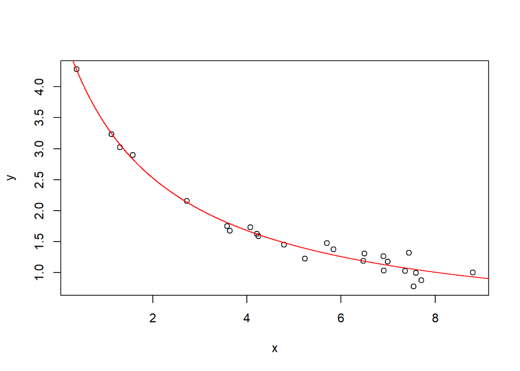

```r
plot(x, y)
x.grid <- seq(from = 0, to = 10, by = 0.001)
lines(x.grid, reg(x.grid, beta), col = 2)
```

### 2.5.5 Linear programming

변수들의 선형식에 의한 제약 조건 하에 최적의 선형결합을 찾는 문제를 선형계획법 문제라 한다. 다음은 제약 조건
$$\begin{eqnarray*}
x_1 + 2 x_2 + 3 x_3 &\le& 9 \\
3 x1 + 2 x_2 + 2 x_3 &\le& 15
\end{eqnarray*}$$

하에 목적함수 $x_1 + 9 x_2 + x_3$를 최대로 하는 $(x_1, x_2, x_3)$를 찾는 예이다.

```r
library(lpSolve)

f.obj <- c(1, 9, 1)
f.con <- matrix(c(1, 2, 3,
                  3, 2, 2),
                nrow = 2, byrow = TRUE)
f.dir <- c("<=", "<=")
f.rhs <- c(9, 15)

res <- lp(direction = "max", objective.in = f.obj,
          const.mat = f.con,
          const.dir = f.dir,
          const.rhs = f.rhs)
res$solution
```

```
## [1] 0.0 4.5 0.0
```

```r
res$objval
```

```
## [1] 40.5
```

#### Convex hull

주어진 데이터 $({\mathbf x}_1, y_1), ({\mathbf x}_2, y_2), \cdots,({\mathbf x}_n, y_n)$가 구축하는 convex hull의 위쪽 경계(boundary)를 함수로 표현하면 다음과 같다.
$$g({\mathbf x}) = \max\left\{\sum_{i=1}^n\gamma_i y_i\,\left|\,
\sum_{i=1}^n\gamma_i {\mathbf x}_i = {\mathbf x},\,
\sum_{i=1}^n \gamma_i = 1
\mbox{ for some }\gamma_i\ge 0, i=1,2,...,n\right.\right\}$$

```r
convexhull <- function(x0, X, Y, direction = "upper")
{
  X <- as.matrix(X)
  n <- nrow(X)
  p <- ncol(X)
  f.obj <- Y
  f.con <- rbind(t(X), rep(1, n))
  f.dir <- rep("==", p + 1)
  f.rhs <- c(x0, 1)
  dir <- ifelse(direction == "lower", "min", "max")

  library(lpSolve)
  res <- lp(direction = dir, objective.in = f.obj,
            const.mat = f.con,
            const.dir = f.dir,
            const.rhs = f.rhs)

  return(list(g = res$objval, gamma = res$solution))
}
```

다음은 모의실험으로 $y = \sqrt{x}$를 경계함수로 갖도록 자료점 50개를 생성해 convex hull을 계산하고 실제 경계함수와 비교하는 예제이다. 매 자료점마다 LP를 풀어서 얻은 $\gamma_i$ 값들을 살펴보면 convex hull의 꼭지점을 알 수 있다. 꼭지점의 경우 해당 $\gamma_i$ 값만 1이고 나머지는 0이 된다. 예를 들어 10번째 자료점이 꼭지점이라면 $\gamma_{10}$의 값만 1이고 나머지 $\gamma_i$ 값들은 모두 0이다.

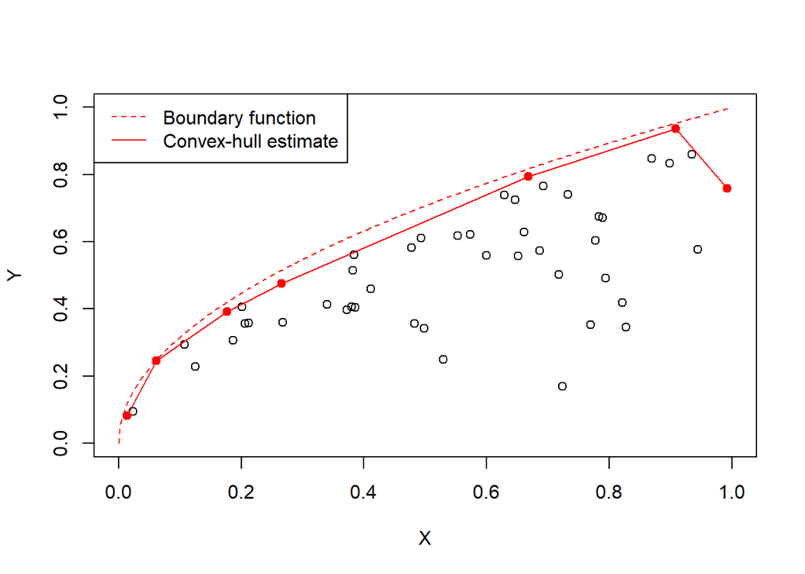

```r
set.seed(1)
n <- 50
X <- sort(runif(n))
Y <- sqrt(X) * exp(-rexp(n, rate = 3))
plot(X, Y, xlim = c(0, 1), ylim = c(0, 1))

# identify vertices of conv-hull
vertex <- rep(FALSE, n)
eps <- 1e-6
for ( i in 1:n ) {
  res <- convexhull(X[i], X, Y)
  if ( max(res$gamma) >= 1 - eps )
    vertex[i] <- TRUE
}

Vx <- X[vertex]
Vy <- Y[vertex]
points(Vx, Vy, col = 2, pch = 19)
lines(Vx, Vy, col = 2)
z <- seq(from = 0, to = 1, by = 0.0025)
lines(z, sqrt(z), col = 2, lty = 2)
legend("topleft", c("Boundary function", "Convex-hull estimate"),
       col = c(2, 2), lty = c(2, 1))
```